# PROPUESTA WEBINAR ARGENTINA- JÚLIA ALSINA

# Diseño web exclusiva

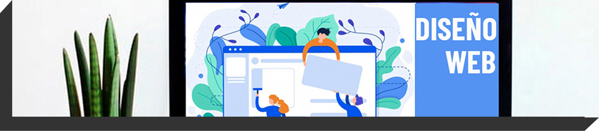

Web exclusiva:

- Creación de la web de presentación del evento, compuesta por dos páginas:
  - Incluirá un video o imagen de bienvenida, un formulario de inscripción y la información de contacto
  - Incluirá la presentación de los ponentes.
- Dominio y alojamiento para la web del evento durante 3 meses
- La web incluirá el logo de la empresa y los colores corporativos.

# Formulario de registro

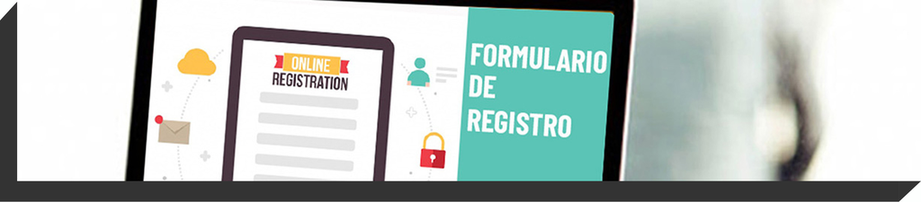

Formulario de registro:

- Formulario de registro personalizado, incluyendo aquellos campos que sean necesarios.
- Una vez un participante se registra, le enviaremos por e.mail la confirmación de registro incluyendo el link al ZOOM del evento y un link con la posibilidad de incluir el evento en su calendario.
- Gestionaremos los datos recogidos, obtendremos un listado de contactos y todos los datos se recogerán en una hoja de excel y se os enviarán.
- Enviaremos e.mails de recordatorio el día anterior al evento incluyendo de nuevo el link ak ZOOM.

# Marketing digital

[figure not shown]

Marketing digital del evento:

- Maquetación de una newsletter basada en plantilla y gestión del envío a la base de datos que ya tenga la empresa.
- Creación y seguimiento de una campaña de publicidad en Linkedin Argentina
- Creación y seguimiento de una campaña de Google Adwords en Argentina

# Producción

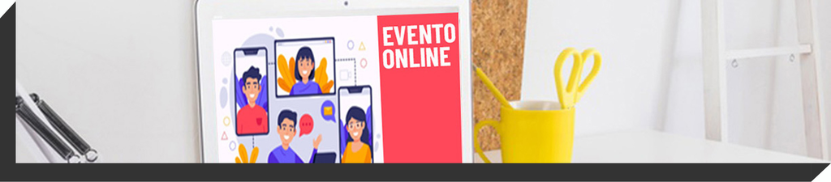

Producción del evento:

- Ensayo general previo al evento con los ponentes.
- Creación de fondo de pantalla de ZOOM personalizado, incluyendo el logo de la empresa y colores corporativos.
- Contratación del pack de webinar de ZOOM de hasta 500 participantes, incluyendo Q&A, chat, encuestas y entradas diferenciadas de diferentes roles: ponentes y asistentes.
- Coordinación de las presentaciones de los ponentes y de la interacción con los asistentes durante el evento.

# Post-evento

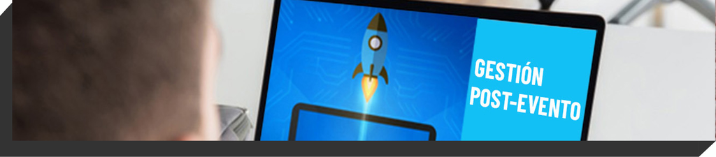

Post-evento:

- Edición y publicación del video del evento en la web y envío del original y el editado al cliente.
- Publicación de la documentación que nos envíen los ponentes.

# Presupuesto

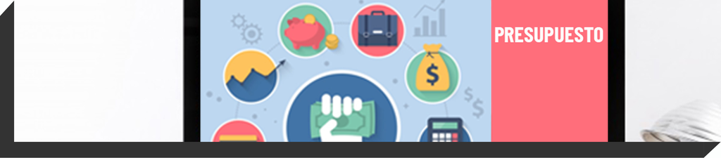

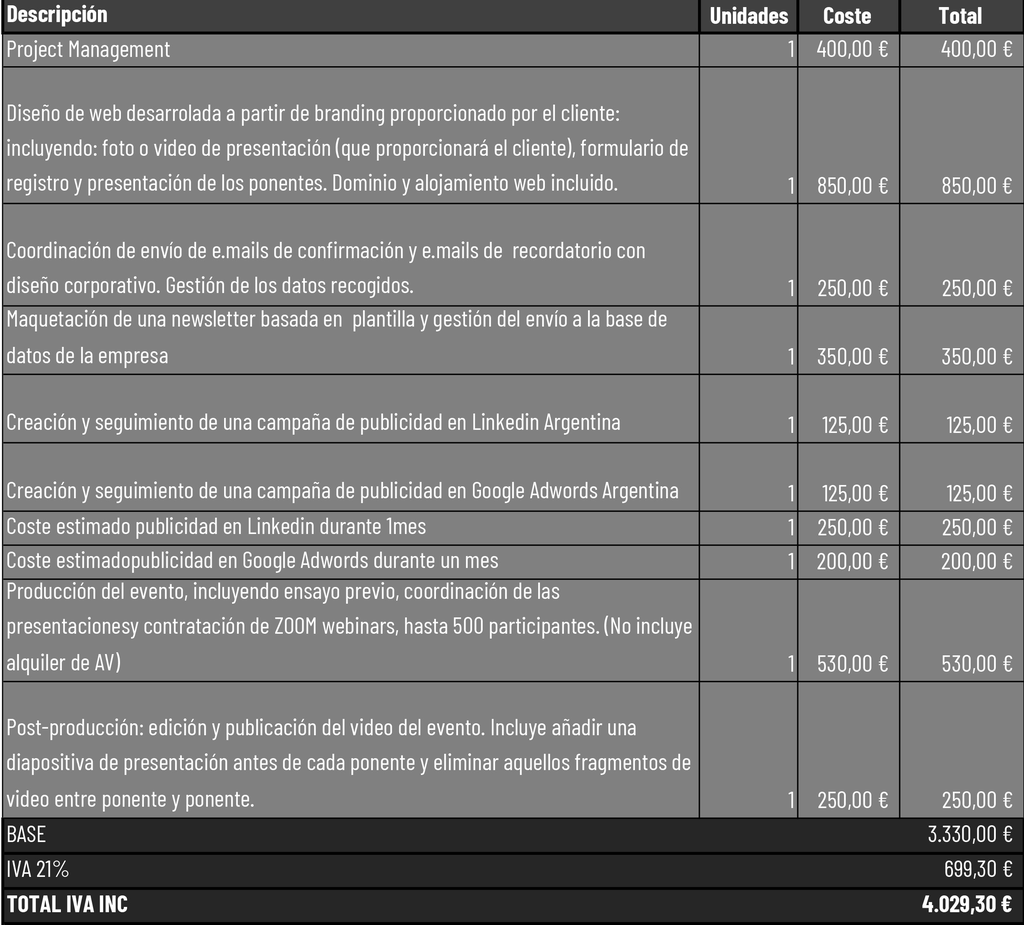

## Notas Importantes

[Contacta con nosotros para más información.](https://www.cuttevents.online/contacto)